# CSC321H5 Project 3.

**Deadline**: Thursday, March. 19, by 9pm

**Submission**: Submit a PDF export of the completed notebook.

**Late Submission**: Please see the syllabus for the late submission criteria.

In this assignment, we will build a convolutional neural network that can predict whether two shoes are from the **same pair** or from two **different pairs**. This kind of application can have real-world applications: for example to help people who are visually impaired to have more independence.

We will explore two convolutional architectures. While we will give you starter code to help make data processing a bit easier, you'll have a chance to build your neural network all by yourself!

You may modify the starter code as you see fit, including changing the signatures of functions and adding/removing helper functions. However, please make sure that your TA can understand what you are doing and why.

If you find exporting the Google Colab notebook to be difficult, you can create your own PDF report that includes your code, written solutions, and outputs that the graders need to assess your work.

```python
import pandas
import numpy as np
import matplotlib.pyplot as plt

import time
import random

import torch
import torch.nn as nn
import torch.optim as optim
```

## Question 1. Data

Download the data from the course website at https://www.cs.toronto.edu/~lczhang/321/files/p3data.zip

Unzip the file. There are three main folders: `train`, `test_w` and `test_m`. Data in `train` will be used for training and validation, and the data in the other folders will be used for testing. This is so that the entire class will have the same test sets.

We've separated `test_w` and `test_m` so that we can track our model performance for women's shoes and men's shoes separately. Each of the test sets contain images from 10 students who submitted images of either exclusively men's shoes or women's shoes.

Upload this data to Google Colab. Then, mount Google Drive from your Google Colab notebook:

```python
from google.colab import drive
drive.mount('/content/gdrive')
```

After you have done so, read this entire section (ideally this entire handout) before proceeding. There are right and wrong ways of processing this data. If you don't make the correct choices, you may find yourself needing to start over. Many machine learning projects fail because of the lack of care taken during the data processing stage.

### Part (a) -- 1 pts

Why might we care about the accuracies of the men's and women's shoes as two separate measures? Why would we expect our model accuracies for the two groups to be different?

Recall that your application may help people who are visually impaired.

```python
# Your answer goes here. Please make sure it is not cut off
"""
By keeping track of a different test accuracy for men's and women's shoes,
we are able to determine if our model has overfit to identify men's or women's
shoes due to the amount of men's or women's shoes present in our training data
By having one be higher than the other, we can correct an overfit by evening
out the ratio of men's to women's shoes in the training data or tune the hyperparameters
to account for this difference.
"""
```

[output not shown]

### Part (b) -- 4 pts

Load the training and test data, and separate your training data into training and validation. Create the numpy arrays `train_data`, `valid_data`, `test_w` and `test_m`, all of which should be of shape `[*, 3, 2, 224, 224, 3]`. The dimensions of these numpy arrays are as follows:

- `*` - the number of students allocated to train, valid, or test
- `3` - the 3 pairs of shoes submitted by that student
- `2` - the left/right shoes
- `224` - the height of each image
- `224` - the width of each image
- `3` - the colour channels

So, the item `train_data[4,0,0,:,:,:]` should give us the left shoe of the first image submitted by the 5th student.The item `train_data[4,0,1,:,:,:]` should be the right shoe in the same pair. The item `train_data[4,1,1,:,:,:]` should be the right shoe in a different pair, submitted by the same student.

When you first load the images using (for example) `plt.imread`, you may see a numpy array of shape `[224, 224, 4]` instead of `[224, 224, 3]`. That last channel is the alpha channel for transparent pixels, and should be removed. The pixel intensities are stored as an integer between 0 and 255. Divide the intensities by 255 so that you have floating-point values between 0 and 1. Then, subtract 0.5 so that the elements of `train_data`, `valid_data` and `test_data` are between -0.5 and 0.5. **Note that this step actually makes a huge difference in training!**

This function might take a while to run---it takes 3-4 minutes for me to just load the files from Google Drive. If you want to avoid running this code multiple times, you can save your numpy arrays and load it later: https://docs.scipy.org/doc/numpy/reference/generated/numpy.save.html

```python
# Your code goes here. Make sure it does not get cut off
# You can use the code below to help you get started. You're welcome to modify
# the code or remove it entirely: it's just here so that you don't get stuck
# reading files

import glob
path = "C:/Users/aaron/Documents/School/CSC321/Projects/Project 3/data/train/*.jpg" # edit me
images = []
# we have a total of 678 images in the training folder, 678/2 = 339 pairs of shoes, 339/3 = 113 students
# we will use the last 11 students' images out of our 113 total for the validation set (last 66/678)
for file in glob.glob(path):
    filename = file.split("/")[-1]   # get the name of the .jpg file
    img = plt.imread(file)           # read the image as a numpy array
    img = img[:, :, :3] # remove the alpha channel
    img = (img/255)-0.5 # apply modifications from instructions
    images.append(img)

train_data = []
valid_data = []
index = 0
for student in range(int((len(images))/6)):
    submission = []
    for pair in range(3):
        shoes = []
        for side in range(2):
            shoes.append(images[index])
            index+=1
        submission.append(np.stack(shoes, axis=0))
    if index >= 611:
        valid_data.append(np.stack(submission, axis=0))
    else:
        train_data.append(np.stack(submission, axis=0))
valid_data = np.array(valid_data)
train_data = np.array(train_data)

# for test_m
path = "C:/Users/aaron/Documents/School/CSC321/Projects/Project 3/data/test_m/*.jpg" # edit me
images = []
for file in glob.glob(path):
    filename = file.split("/")[-1]   # get the name of the .jpg file
    img = plt.imread(file)           # read the image as a numpy array
    img = img[:, :, :3] # remove the alpha channel
    img = (img/255)-0.5 # apply modifications from instructions
    images.append(img)

test_m = []
index = 0
for student in range(int((len(images))/6)):
    submission = []
    for pair in range(3):
        shoes = []
        for side in range(2):
            shoes.append(images[index])
            index+=1
        submission.append(np.stack(shoes, axis=0))
    test_m.append(np.stack(submission, axis=0))
test_m = np.array(test_m)


# for test_w
path = "C:/Users/aaron/Documents/School/CSC321/Projects/Project 3/data/test_w/*.jpg" # edit me
images = []
for file in glob.glob(path):
    filename = file.split("/")[-1]   # get the name of the .jpg file
    img = plt.imread(file)           # read the image as a numpy array
    img = img[:, :, :3] # remove the alpha channel
    img = (img/255)-0.5 # apply modifications from instructions
    images.append(img)


test_w = []
index = 0
for student in range(int((len(images))/6)):
    submission = []
    for pair in range(3):
        shoes = []
        for side in range(2):
            shoes.append(images[index])
            index+=1
        submission.append(np.stack(shoes, axis=0))
    test_w.append(np.stack(submission, axis=0))
test_w = np.array(test_w)
```

```
Clipping input data to the valid range for imshow with RGB data ([0..1] for floats or [0..255] for integers).
Clipping input data to the valid range for imshow with RGB data ([0..1] for floats or [0..255] for integers).
Clipping input data to the valid range for imshow with RGB data ([0..1] for floats or [0..255] for integers).
```

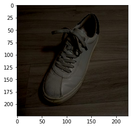

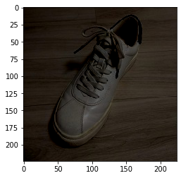

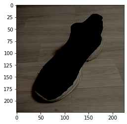

```python
# Run this code, include the image in your PDF submission
plt.figure()
plt.imshow(train_data[4,0,0,:,:,:]) # left shoe of first pair submitted by 5th student
plt.figure()
plt.imshow(train_data[4,0,1,:,:,:]) # right shoe of first pair submitted by 5th student
plt.figure()
plt.imshow(train_data[4,1,1,:,:,:]) # right shoe of second pair submitted by 5th student
```

### Part (c) -- 2 pts

Since we want to train a model that determines whether two shoes come from the **same** pair or **different** pairs, we need to create some labelled training data. Our model will take in an image, either consisting of two shoes from the **same pair** or from **different pairs**. So, we'll need to generate some *positive examples* with images containing two shoes that *are* from the same pair, and some *negative examples* where images containing two shoes that *are not* from the same pair. We'll generate the *positive examples* in this part, and the *negative examples* in part (c).

Write a function `generate_same_pair()` that takes one of the data sets that you produced in part (a), and generates a numpy array where each pair of shoes in the data set is concatenated together. In particular, we'll be concatenating together images of left and right shoes along the **height** axis. Your function `generate_same_pair` should return a numpy array of shape `[*, 448, 224, 3]`.

(Later on, we will need to convert this numpy array into a PyTorch tensor with shape `[*, 3, 448, 224]`. For now, we'll keep the RGB channel as the last dimension since that's what `plt.imshow` requires)

```
(101, 3, 2, 224, 224, 3)
(303, 448, 224, 3)
```

```
Clipping input data to the valid range for imshow with RGB data ([0..1] for floats or [0..255] for integers).
```

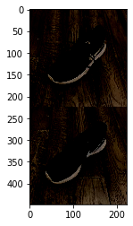

```python
# Your code goes here
def generate_same_pair(data):
    out = np.ndarray((np.shape(data)[0]*3, 448, 224, 3))
    for student in range(np.shape(data)[0]):
        for shoes in range(3):
            out[student*3 + shoes, :224, :, :] = data[student, shoes, 0, :, :, :]
            out[student*3 + shoes, 224:, :, :] = data[student, shoes, 1, :, :, :]
    return out

# Run this code, include the result with your PDF submission
print(train_data.shape) # if this is [N, 3, 2, 224, 224, 3]
print(generate_same_pair(train_data).shape) # should be [N*3, 448, 224, 3]
plt.imshow(generate_same_pair(train_data)[0]) # should show 2 shoes from the same pair
```

### Part (d) -- 2 pts

Write a function `generate_different_pair()` that takes one of the data sets that you produced in part (a), and generates a numpy array in the same shape as part (b). However, each image will contain 2 shoes from a **different** pair, but submitted by the **same student**. Do this by jumbling the 3 pairs of shoes submitted by each student.

Theoretically, for each student image submissions, there are 6 different combinations of "wrong pairs" that we could produce. To keep our data set *balanced*, we will only produce **three** combinations of wrong pairs per unique person. In other words,`generate_same_pairs` and `generate_different_pairs` should return the same number of training examples.

```
(101, 3, 2, 224, 224, 3)
(303, 448, 224, 3)
```

```
Clipping input data to the valid range for imshow with RGB data ([0..1] for floats or [0..255] for integers).
```

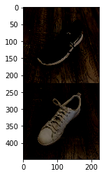

```python
# Your code goes here
def generate_different_pair(data):
    out = np.ndarray((np.shape(data)[0]*3, 448, 224, 3))
    for student in range(np.shape(data)[0]):
        for shoes in range(3):
            out[student*3 + shoes, :224, :, :] = data[student, shoes, 0, :, :, :]
            out[student*3 + shoes, 224:, :, :] = data[student, (shoes+1)%3, 1, :, :, :]
    return out

# Run this code, include the result with your PDF submission
print(train_data.shape) # if this is [N, 3, 2, 224, 224, 3]
print(generate_different_pair(train_data).shape) # should be [N*3, 448, 224, 3]
plt.imshow(generate_different_pair(train_data)[0]) # should show 2 shoes from different pairs
```

### Part (e) -- 1 pts

Why do we insist that the different pairs of shoes still come from the same student? (Hint: what else do images from the same student have in common?)

```python
# Your answer goes here. Please make sure it is not cut off
"""
We insist that the different pairs of shoes still come from the same student because this way we are able to
(hopefully) keep the same background features so that the biggest difference between each image is the shoe and
not anything in the background like the lighting or texture. Also, each student cannot upload the same pair of
shoes twice, so we can gurantee that we can generate different pairs from their data.
"""
```

[output not shown]

### Part (f) -- 1 pts

Why is it important that our data set be *balanced*? In other words suppose we created a data set where 99% of the images are of shoes that are *not* from the same pair, and 1% of the images are shoes that *are* from the same pair. Why could this be a problem?

```python
# Your answer goes here. Please make sure it is not cut off
"""
It is important that our data set be balanced because if we had a data set where 99% of
the images are of shoes that are not from the same pair, and 1% of the images are shoes
that are from the same pair, our model would be more inclined to predict that two given
shoes are from a different pair rather than the same pair.
"""
```

[output not shown]

## Question 2. Convolutional Neural Networks

Before starting this question, we recommend reviewing the lecture and tutorial materials on convolutional neural networks.

In this section, we will build two CNN models in PyTorch.

### Part (a) -- 4 pts

Implement a CNN model in PyTorch called `CNN` that will take images of size $3 \times 448 \times 224$, and classify whether the images contain shoes from the same pair or from different pairs.

The model should contain the following layers:

- A convolution layer that takes in 3 channels, and outputs $n$ channels.
- A $2 \times 2$ downsampling (either using a strided convolution in the previous step, or max pooling)
- A second convolution layer that takes in $n$ channels, and outputs $n \times 2$ channels.
- A $2 \times 2$ downsampling (either using a strided convolution in the previous step, or max pooling)
- A third convolution layer that takes in $n \times 2$ channels, and outputs $n \times 4$ channels.
- A $2 \times 2$ downsampling (either using a strided convolution in the previous step, or max pooling)
- A fourth convolution layer that takes in $n \times 4$ channels, and outputs $n \times 8$ channels.
- A $2 \times 2$ downsampling (either using a strided convolution in the previous step, or max pooling)
- A fully-connected layer with 100 hidden units
- A fully-connected layer with 2 hidden units

Make the variable $n$ a parameter of your CNN. You can use either $3 \times 3$ or $5 \times 5$ convolutions kernels. Set your padding to be `(kernel_size - 1) / 2` so that your feature maps have an even height/width.

Note that we are omitting certain steps that practitioners will typically not mention, like ReLU activations and reshaping operations. Use the tutorial materials and your past projects to figure out where they are.

```python
class CNN(nn.Module):
    def __init__(self, n=4):
        super(CNN, self).__init__()
        self.n = n
        self.conv1 = nn.Conv2d(in_channels=3, out_channels=n, kernel_size=5, stride=2, padding=2)
        self.conv2 = nn.Conv2d(in_channels=n, out_channels=n*2, kernel_size=5, stride=2, padding=2)
        self.conv3 = nn.Conv2d(in_channels=n*2, out_channels=n*4, kernel_size=5, stride=2, padding=2)
        self.conv4 = nn.Conv2d(in_channels=n*4, out_channels=n*8, kernel_size=5, stride=2, padding=2)
        self.fc1 = nn.Linear(in_features=14*28*8*n, out_features=100)
        self.fc2 = nn.Linear(in_features=100, out_features=2)

    def forward(self, inp):
        x = inp.transpose(2, 3)
        c1 = torch.relu(self.conv1(x))
        c2 = torch.relu(self.conv2(c1))
        c3 = torch.relu(self.conv3(c2))
        c4 = torch.relu(self.conv4(c3))
        c5 = torch.relu(self.fc1(c4.flatten(1, 3)))
        c6 = self.fc2(c5)
        return c6
```

### Part (b) -- 4 pts

Implement a CNN model in PyTorch called `CNNChannel` that contains the same layers as in the Part (a), but with one crucial difference: instead of starting with an image of shape $3 \times 448 \times 224$, we will first manipulate the image so that the left and right shoes images are concatenated along the **channel** dimension.

[figure not shown]

Complete the manipulation in the `forward()` method (by slicing and using the function `torch.cat`). The input to the first convolutional layer should have 6 channels instead of 3 (input shape $6 \times 224 \times 224$).

Use the same hyperparameter choices as you did in part (a), e.g. for the kernel size, choice of downsampling, and other choices.

```python
class CNNChannel(nn.Module):
    def __init__(self, n=4):
        super(CNNChannel, self).__init__()
        self.n = n
        self.conv1 = nn.Conv2d(in_channels=6, out_channels=n, kernel_size=5, stride=2, padding=2)
        self.conv2 = nn.Conv2d(in_channels=n, out_channels=n*2, kernel_size=5, stride=2, padding=2)
        self.conv3 = nn.Conv2d(in_channels=n*2, out_channels=n*4, kernel_size=5, stride=2, padding=2)
        self.conv4 = nn.Conv2d(in_channels=n*4, out_channels=n*8, kernel_size=5, stride=2, padding=2)
        self.fc1 = nn.Linear(in_features=14*14*8*n, out_features=100)
        self.fc2 = nn.Linear(in_features=100, out_features=2)

    def forward(self, inp):
        x = inp.transpose(2, 3)
        left = x[:, :, :224, :]
        right = x[:, :, 224:, :]
        merged = torch.cat((left, right), dim=1)
        c1 = torch.relu(self.conv1(merged))
        c2 = torch.relu(self.conv2(c1))
        c3 = torch.relu(self.conv3(c2))
        c4 = torch.relu(self.conv4(c3))
        c5 = torch.relu(self.fc1(c4.flatten(1, 3)))
        c6 = self.fc2(c5)
        return c6
```